# Learning models

2024-08-17

## This markdown is supposed to highlight one of the main advantages of STAN. Models that have some temporal component (i.e. there are latent variables that depend on previous trials) can either be a pain or impossible to estimate in the “normal” framework of statistical modeling. However, with stan this becomes intuitive and easy!

### We start by simulating some data where participants learn cue-stimulus associations. For simplicity we simulate this association directly as 0 or 1’s (these are what the simulated participants need to learn). In order to make it a dynamic learning experiment we can simulate that the association between the cue and stimulus changes with trials. Say the association starts bring 80% and then swaps to 20% after 20 trials.

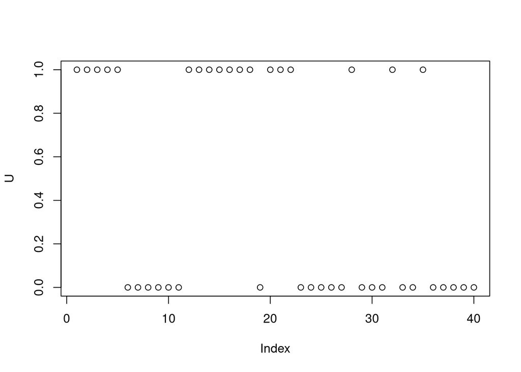

```r
U = c(rbinom(20,1,0.8),rbinom(20,1,0.2))
plot(U)
```

### Theories of learning tell us that people update their belief in proportion to the prediction error. I.e., the more wrong you were, the more you update your beliefs. One conceptualization of this is the rescorla Wagner learning model which follows the mathematical update equation:

$$\underbrace{E^{t+1}}_{\text{new expectation}} =
\underbrace{E^{t}}_{\text{last
expectation}}+\underbrace{\alpha}_{\text{Learning rate}}*
\underbrace{(U^{t}-E^{t})}_{\text{prediction error}}$$

What this equation entails is that on each trial participants have an expectation (E(t)) that is compared to the actual input (U) and the difference between these two quantities are then multiplied by a subject level learning rate $\alpha$ which together gives how much ones belief is updated on a given trial.